# Padres_Inf

0. ¿Qué vamos a construir?

Una app de Flet que muestra una lista de videos (“Padres de la informática”) con título y descripción, y dos botones para ir Anterior / Siguiente. Todo en una sola ventana.

1. Requisitos e instalación 1.1. Instala Python 3.10+

Windows/macOS: verifica en la terminal:

```python
python --version
# o
python3 --version
```

1.2. Crea una carpeta llamada padres_informatica

1.3-Crea tu entorno virtual.

```python
python -m venv .venv
.venv\Scripts\activate
```

1.4-Instala flet

```python
pip install flet[all]
```

1.5-Crea tu proyecto

```python
flet create informatica
```

1.6-Instala dependencias

```python
pip install flet flet-video
```

1.7-Cómo agregar tus videos (Drive o GitHub) Opción A: Google Drive

Sube tus archivos .mp4 a Google Drive.

Haz clic derecho en el archivo → “Compartir” → selecciona “Cualquiera con el enlace”.

Copia el enlace que se ve así:

```python
https://drive.google.com/file/d/11quy5gjxoZLasWd2SvL-PSynA4JWY209/view?usp=sharing
```

Cambia la parte /file/d/ID/view?usp=sharing por:

```python
https://drive.google.com/uc?export=download&id=11quy5gjxoZLasWd2SvL-PSynA4JWY209
```

🔸 El ID es la cadena entre “/d/” y “/view?” Ejemplo: 11quy5gjxoZLasWd2SvL-PSynA4JWY209

Opción B: GitHub (recomendada para proyectos técnicos)

Esta opción es ideal si los alumnos están trabajando con repositorios o documentando sus evidencias en GitHub.

Pasos

Crea un repositorio o usa uno existente, por ejemplo: https://github.com/ProfeLuisTic1986/Recursos_Videos

Sube tus videos .mp4 al repositorio (en la carpeta principal o dentro de una carpeta videos/).

Una vez subido el video, haz clic sobre él para abrirlo. Verás una URL similar a:

```python
https://github.com/ProfeLuisTic1986/Recursos_Videos/blob/main/babbage.mp4
```

Para obtener el enlace directo (raw), puedes hacerlo de dos formas:

a) Manualmente:

Reemplaza github.com por raw.githubusercontent.com

Elimina la parte /blob/

Resultado:

```python
https://raw.githubusercontent.com/ProfeLuisTic1986/Recursos_Videos/main/babbage.mp4
```

b) Automáticamente (usando ChatGPT):

Copia el enlace normal de GitHub (como el anterior).

Abre ChatGPT y escríbele:

```python
Convierte este enlace de GitHub en un enlace directo (raw) para poder usarlo en Flet o para reproducir un video:

https://github.com/ProfeLuisTic1986/Recursos_Videos/blob/main/babbage.mp4
```

ChatGPT te responderá con el formato correcto:

```python
https://raw.githubusercontent.com/ProfeLuisTic1986/Recursos_Videos/main/babbage.mp4
```

Ese es el enlace que debes usar en tu código:

```python
"video": "https://raw.githubusercontent.com/ProfeLuisTic1986/Recursos_Videos/main/babbage.mp4"
```

Consejos importantes

- Asegúrate de que tu repositorio sea público, de lo contrario los videos no se cargarán.
- Mantén nombres sencillos para tus archivos: babbage.mp4, ada.mp4, pascal.mp4.
- Si tus videos son grandes (más de 25 MB), considera subirlos a Google Drive y usar la opción A.
2. Estructura básica de una app Flet

Primero, abre main.py y crea el esqueleto mínimo:

```python
import flet as ft

def main(page: ft.Page):
    page.title = "Padres de la informática"

ft.app(target=main)
```

Qué está pasando:

- ft.Page es la ventana principal.
- ft.app(target=main) arranca la app y llama a main(page).
3. Personaliza la ventana (Page)

Agrega color de fondo y un tamaño cómodo para el contenido:

```python
def main(page: ft.Page):
    page.title = "Padres de la informática"
    page.bgcolor = ft.Colors.BLACK87
```

4. Declara los datos (tu playlist)

Creamos una lista de diccionarios con titulo, descripcion y video:

```python
videos = [
    {
        "titulo": "Charles Babbage",
        "descripcion": "Conocido como el padre de la computadora...",
        "video": "https://drive.google.com/uc?export=download&id=11quy5gjxoZLasWd2SvL-PSynA4JWY209"
    },
    {
        "titulo": "Ada Lovelace",
        "descripcion": "Ada Lovelace fue reconocida como la primera programadora.",
        "video": "https://drive.google.com/uc?export=download&id=1evn_myd6_yyNuXtXHt5r6eqJ4H2QjgU6"
    },
    {
        "titulo": "Blaise Pascal",
        "descripcion": "Blaise Pascal fue matemático, físico y filósofo francés...",
        "video": "https://drive.google.com/uc?export=download&id=1_fHCHd_vKIYKlZvf0XVChWRyD1i-HoRG"
    }
]
```

5. Estado mínimo: ¿qué video estoy viendo?

Necesitamos recordar el índice actual del video seleccionado. Como las closures de eventos en Flet esperan variables mutables, usaremos una lista con un entero:

```python
indice_actual = [0]  # empieza en el primer video
```

Usar [0] (lista) nos permite hacer indice_actual[0] += 1 dentro de funciones internas sin declarar global.

6. Contenedor donde cambiaremos el contenido

Vamos a preparar un contenedor vacío que luego llenaremos con el video, título, descripción y botones:

```python
contenedor = ft.Container(width=700, height=600)
```

Y agregamos el contenedor a la página, centrado:

```python
page.add(
    ft.Container(
        expand=True,
        alignment=ft.alignment.center,
        content=contenedor
    )
)
```

Idea clave: no reconstruimos toda la página; solo cambiamos el content del contenedor y luego llamamos page.update().

7. Botones y eventos

Creamos los botones Anterior y Siguiente; primero sin lógica:

```python
boton_anterior = ft.ElevatedButton("⏮ Anterior", width=150)
boton_siguiente = ft.ElevatedButton("Siguiente ⏭", width=150)
```

8. Mostrar un video (función que arma la “pantalla”)

Creamos una función que lee el índice, toma el video actual y arma una columna con:

reproductor,

título,

descripción,

fila de botones.

```python
import flet_video as fv

def mostrar_video():
    vid = videos[indice_actual[0]]
    contenedor.content = ft.Column(
        [
            fv.Video(
                expand=True,
                playlist=[fv.VideoMedia(vid["video"])],
                width=600,
                height=350,
                autoplay=True,
                show_controls=True,
            ),
            ft.Text(
                vid["titulo"],
                size=28,
                weight=ft.FontWeight.BOLD,
                color=ft.Colors.WHITE
            ),
            ft.Text(
                vid["descripcion"],
                size=16,
                italic=True,
                text_align=ft.TextAlign.CENTER,
                color=ft.Colors.WHITE70
            ),
            ft.Row(
                [boton_anterior, boton_siguiente],
                alignment=ft.MainAxisAlignment.CENTER,
                spacing=40
            )
        ],
        alignment=ft.MainAxisAlignment.CENTER,
        horizontal_alignment=ft.CrossAxisAlignment.CENTER,
        spacing=15
    )
    page.update()
```

Puntos didácticos:

fv.Video recibe una playlist de VideoMedia. Con una lista de 1 elemento es suficiente.

autoplay=True reproduce al cargar; si tu SO bloquea el auto-play con sonido, dale clic al “play” o siléncialo.

Después de cambiar contenedor.content, siempre page.update() para ver los cambios.

9. Programar los clics de Anterior y Siguiente

Sumamos y restamos el índice con módulo para “dar la vuelta”:

```python
def anterior_click(e):
    indice_actual[0] = (indice_actual[0] - 1) % len(videos)
    mostrar_video()

def siguiente_click(e):
    indice_actual[0] = (indice_actual[0] + 1) % len(videos)
    mostrar_video()

boton_anterior.on_click = anterior_click
boton_siguiente.on_click = siguiente_click
```

Usar % len(videos) evita errores cuando llegamos al principio o final de la lista.

10. Orden de ejecución en main

El orden típico:

Configurar page

Declarar videos y estado (indice_actual)

Crear contenedor y agregarlo a la página

Crear botones

Definir mostrar_video() y los eventos

Llamar a mostrar_video() por primera vez

11. Código final completo

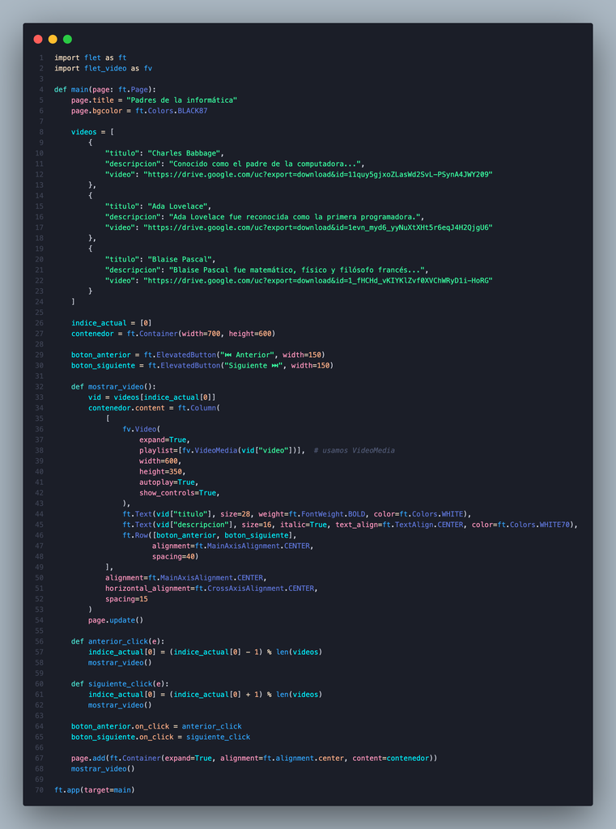

12. Errores comunes y soluciones rápidas

No se reproduce el video

Revisa que el enlace sea uc?export=download&id=... y que el archivo en Drive esté compartido como “Cualquiera con el enlace”.

Confirma que el archivo es .mp4 H.264/AAC.

Auto-play bloqueado

Algunos sistemas/políticas del navegador bloquean reproducción automática con audio. Dale clic en Play.

Pantalla en negro

Verifica que instalaste flet-video: pip show flet-video.

Cierra otras apps que usen la cámara/codec y vuelve a intentar.

Nada cambia al presionar botones

Asegúrate de que los eventos están asignados: boton_anterior.on_click = anterior_click boton_siguiente.on_click = siguiente_click

Y que siempre llamas page.update() dentro de mostrar_video().

13. Extensiones sugeridas (para tareas o plus en clase)

Más metadatos: agrega “año”, “aporte”, “fuentes” y muéstralos con ft.Text o en ft.ListTile.

Indicador de posición: “Video 1 de 3” (usa ft.Text(f"{indice_actual[0]+1} de {len(videos)}")).

Navegación por teclado: captura eventos de teclado para ←/→.

Diseño responsivo: usa expand=True y page.window_width/height para ajustar tamaños.

Validación: si un enlace falla, muestra un ft.SnackBar con mensaje de error.